# Lab 3: MATH 4753

Clay Curry

2020-09-15

# Task 1

WD

```r
getwd()
```

```
## [1] "C:/Dev/R_Projects/MATH4753CURR0011/Labs/Lab03"
```

# Task 2

**Reading in data set relating heights of spruce trees to breast height diameter. . .**

```r
spruce.df = read.csv("SPRUCE.csv")
head(spruce.df)
```

```
##   BHDiameter Height
## 1       18.9   20.0
## 2       16.6   18.8
## 3       15.5   16.8
## 4       15.5   16.9
## 5       19.4   20.2
## 6       13.7   16.3
```

# Task 3

**Create a scatter plot to view the relationship between Tree Height and BHDiameter**

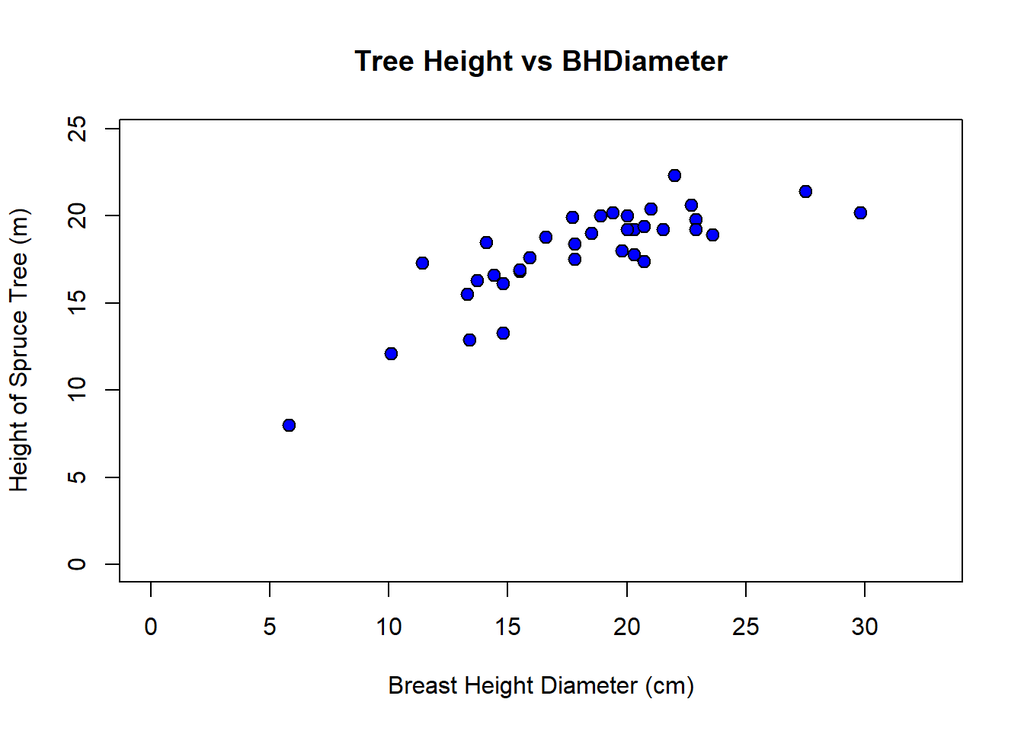

```r
plot(Height~BHDiameter, main = "Tree Height vs BHDiameter", xlab = "Breast Height Diameter (cm)", ylab = "Height of Spruce Tree (m)", pch = 21, bg = "blue", cex = 1.2, xlim = c(0, max(BHDiameter) *1.1), ylim = c(0, max(Height) * 1.1), data = spruce.df)
```

*Does there appear to be a straight line relationship?* In the right half of the plot, there does seem to be a linear relationship. However, for smaller values of BHD, it appears the data set deviates significantly from a linear model. Modeling the entire data set would require some sort of curve.

```r
library(s20x)
lo = layout(matrix(1:3, nr=3, nc = 1, byrow = TRUE))
tsone = trendscatter(Height~BHDiameter, f=0.5, data = spruce.df)
tsone = trendscatter(Height~BHDiameter, f=0.6, data = spruce.df)
tsone = trendscatter(Height~BHDiameter, f=0.7, data = spruce.df)
```

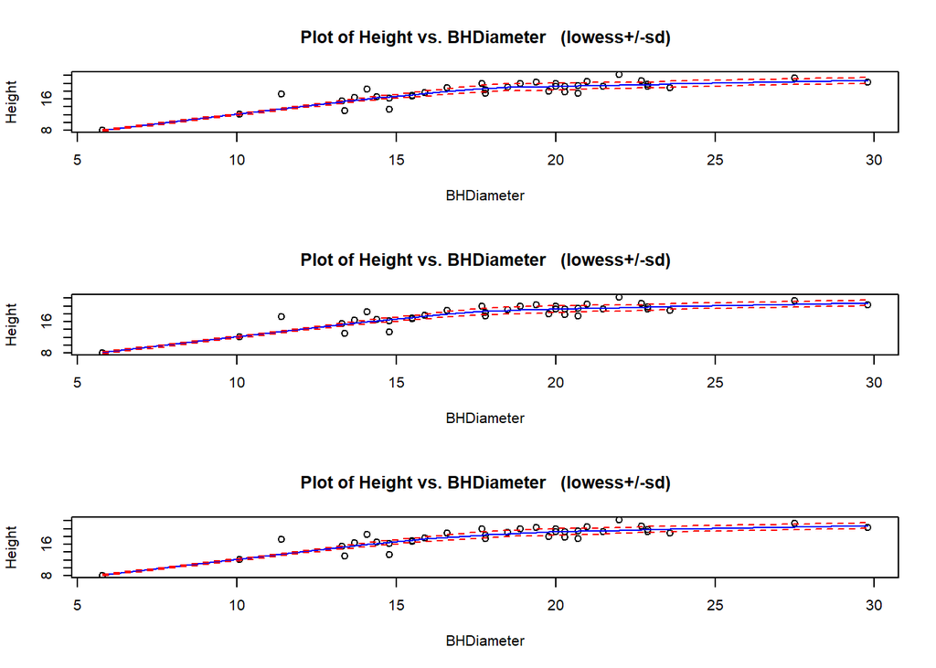

**creating a linear model for spruce.df**

```r
spruce.lm = with(spruce.df, lm(Height~BHDiameter))
```

Make a new scatter plot and add the least squares regression line

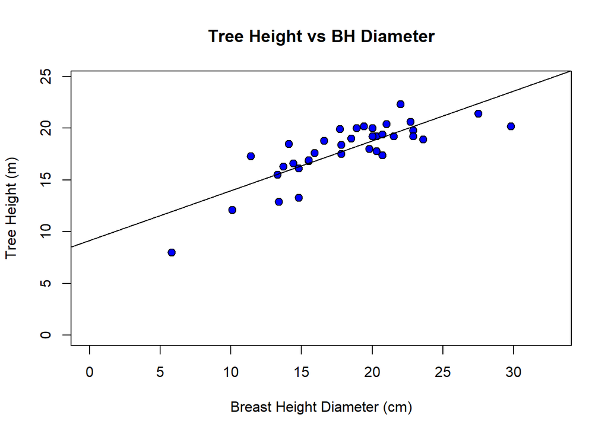

```r
lo = layout(1)
with(spruce.df,
     plot(Height~BHDiameter, main = "Tree Height vs BH Diameter", xlab = "Breast Height Diameter (cm)", ylab = "Tree Height (m)", bg = "Blue", pch=21, cex=1.2, xlim = c(0, max(BHDiameter) *1.1), ylim = c(0, max(Height) * 1.1)
          )
     )

abline(spruce.lm)
```

**Comment on the graph, is a straight line appropriate? Consider the smoother curve also.**

Not quite. The straight line appears to act like a tangent line to the appropriate curve fitting the plot. This is backed up by the trendscatter plot which clearly shows curvature.

# Task 4

## Divide the graphical interface into 4 equal areas, use layout.show(4) and record the picture.

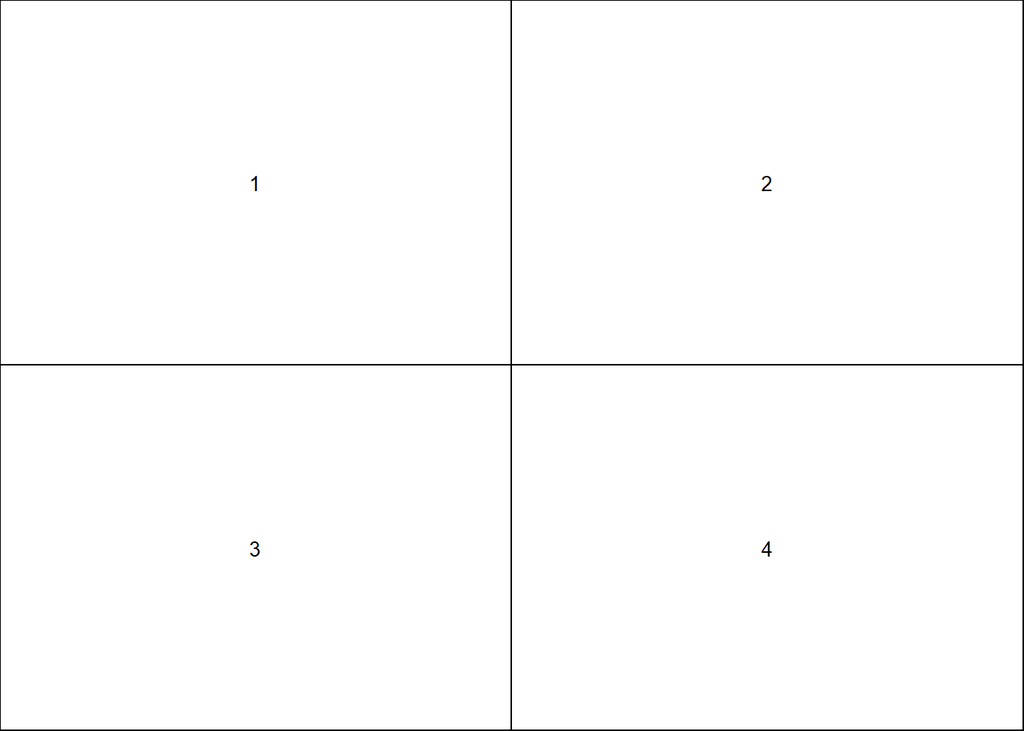

```r
lo = layout(matrix(1:4, nr=2, nc=2, byrow=TRUE))
layout.show(4)
```

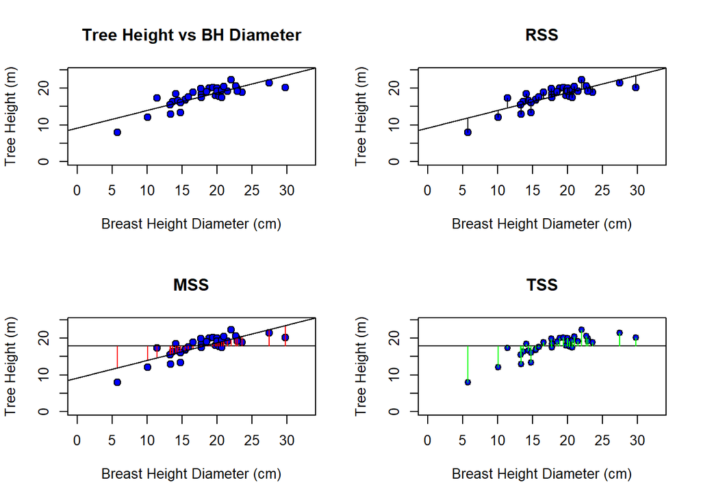

```r
mycex = 1.0
# Scatter plot and fitted line
with(spruce.df,
     plot(Height~BHDiameter, main = "Tree Height vs BH Diameter", xlab = "Breast Height Diameter (cm)", ylab = "Tree Height (m)", bg = "Blue", pch=21, cex=1.2, xlim = c(0, max(BHDiameter) *1.1), ylim = c(0, max(Height) * 1.1))
)
abline(spruce.lm)
# Residual line segments
# make yhat the estimates of E[Height | BHDiameter]
yhat = with(spruce.df, predict(spruce.lm, data.frame(BHDiameter)))
# OR you could use
yhat = fitted(spruce.lm)
with(spruce.df,
     plot(Height~BHDiameter, main = "RSS", xlab = "Breast Height Diameter (cm)", ylab = "Tree Height (m)", bg = "Blue", pch=21, cex=1.2, xlim = c(0, max(BHDiameter) *1.1), ylim = c(0, max(Height) * 1.1))
)
# Draw in segments making the residuals
with(spruce.df,
     {
       segments(BHDiameter, Height, BHDiameter, yhat)
     })
abline(spruce.lm)
with(spruce.df, # MSS
     plot(Height~BHDiameter, main = "MSS", xlab = "Breast Height Diameter (cm)", ylab = "Tree Height (m)", bg = "Blue", pch=21, cex=1.2, xlim = c(0, max(BHDiameter) *1.1), ylim = c(0, max(Height) * 1.1))
)
with(spruce.df, abline(h = mean(Height)))
with(spruce.df, segments(BHDiameter, mean(Height), BHDiameter, yhat, col="Red"))
abline(spruce.lm)
with(spruce.df, #TSS
plot(Height~BHDiameter, bg="Blue", pch=21, main="TSS", xlab = "Breast Height Diameter (cm)", ylab = "Tree Height (m)", xlim=c(0,1.1*max(BHDiameter)), ylim=c(0,1.1*max(Height)))
)
with(spruce.df,abline(h=mean(Height)))
with(spruce.df, segments(BHDiameter,Height,BHDiameter,mean(Height),col="Green"))
```

## Calculate TSS, MSS, and RSS

```r
TSS=with(spruce.df,sum((Height-mean(Height))^2))
TSS
```

```
## [1] 278.9475
```

```r
MSS=with(spruce.df,sum((yhat - mean(Height))^2))
MSS
```

```
## [1] 183.2447
```

```r
RSS=with(spruce.df,sum((Height-yhat)^2))
RSS
```

```
## [1] 95.70281
```

MSS/TSS is R squared, and its relatively low value further supports the idea that the data should be fit using a curve.

## Does TSS = RSS + MSS

```r
RSS + MSS
```

```
## [1] 278.9475
```

equals

```r
TSS
```

```
## [1] 278.9475
```

# Task 5

## summarize

```r
summary(spruce.lm)
```

```
##
## Call:
## lm(formula = Height ~ BHDiameter)
##
## Residuals:
##     Min      1Q  Median      3Q     Max
## -3.9394 -0.9763  0.2829  0.9950  2.6644
##
## Coefficients:
##             Estimate Std. Error t value Pr(>|t|)
## (Intercept)  9.14684    1.12131   8.157 1.63e-09 ***
## BHDiameter   0.48147    0.05967   8.069 2.09e-09 ***
## ---
## Signif. codes:  0 '***' 0.001 '**' 0.01 '*' 0.05 '.' 0.1 ' ' 1
##
## Residual standard error: 1.678 on 34 degrees of freedom
## Multiple R-squared:  0.6569, Adjusted R-squared:  0.6468
## F-statistic:  65.1 on 1 and 34 DF,  p-value: 2.089e-09
```

```r
coef(spruce.lm)
```

```
## (Intercept)  BHDiameter
##   9.1468390   0.4814743
```

# Task 6

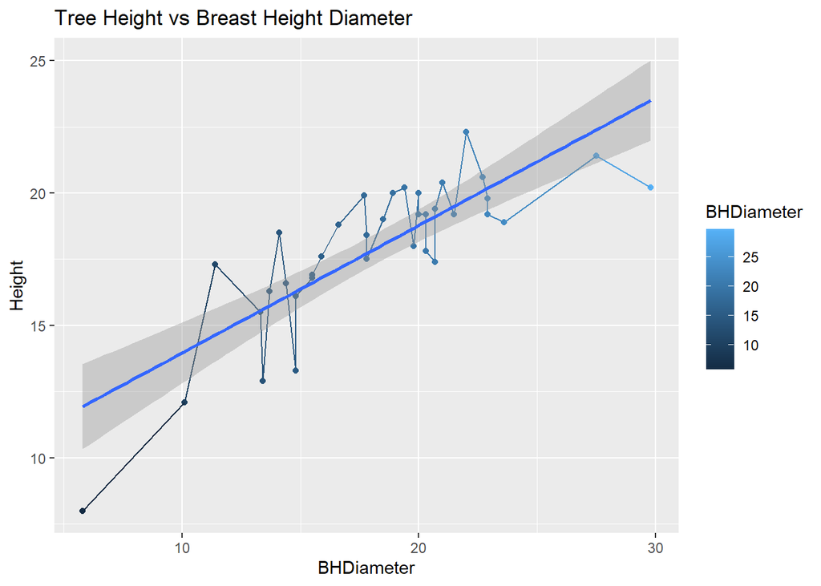

```r
library(ggplot2)
g = ggplot(spruce.df, aes(x=BHDiameter, y=Height, col=BHDiameter))
g = g + geom_point() + geom_line() + geom_smooth(method="lm")
g = g + ggtitle("Tree Height vs Breast Height Diameter")
g
```

# Task 7

This is how you place images in RMD documents

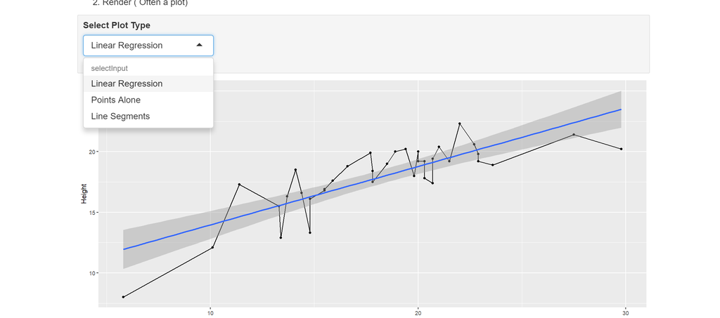

“Linear Regression”

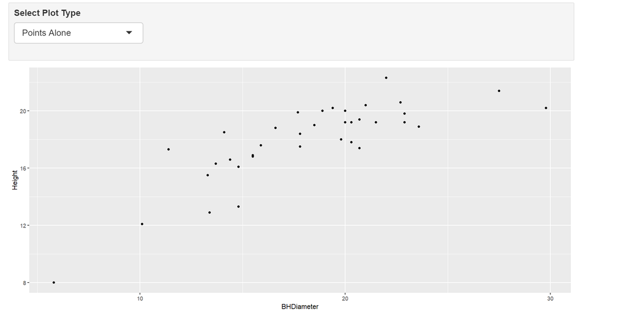

“Points Alone”

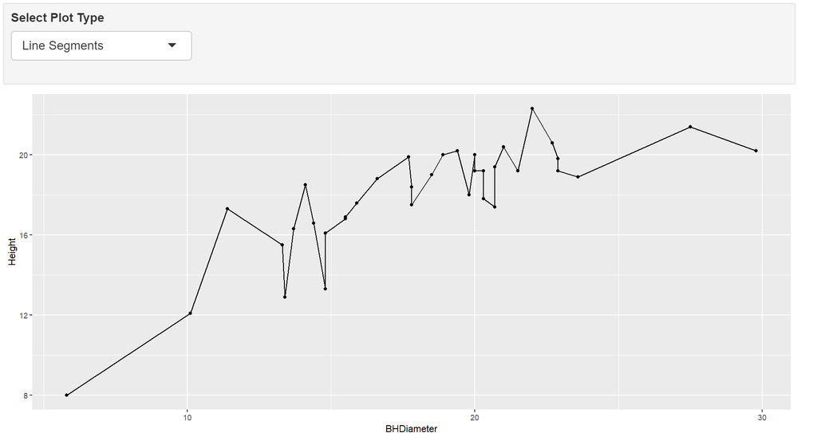